# Простые сети в GNS3. Анализ трафика

Лабораторная работа №5

Гафоров Нурмухаммад

Российский университет дружбы народов, Москва, Россия

30 октября 2025

# Цель работы

Изучить принципы построения простейших сетей на базе коммутатора и маршрутизаторов **FRR** и **VyOS** в среде **GNS3**, а также провести анализ сетевого трафика с помощью программы **Wireshark**.

# Ход выполнения

## Топология сети на коммутаторе

В GNS3 создана сеть, включающая коммутатор и два компьютера (**PC1**, **PC2**).  
Проверена связь между узлами с помощью `ping`.

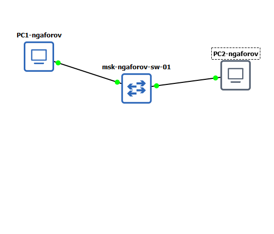

Топология сети в GNS3

## Настройка IP-адресов

- PC1 — **192.168.1.11/24**
- PC2 — **192.168.1.12/24**  
  Шлюз по умолчанию: **192.168.1.1**

[figure not shown]

Настройка IP-адресов

## Анализ ICMP и ARP

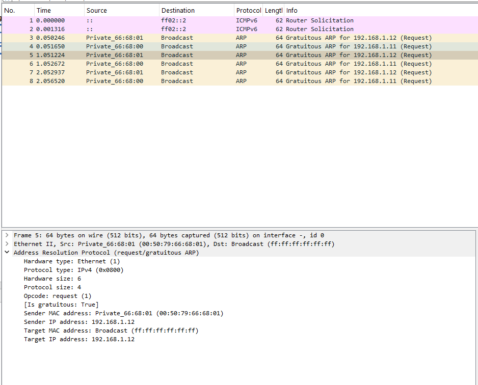

ICMP и ARP трафик

## Анализ UDP и TCP

В режимах `ping udp` и `ping tcp` зафиксированы пакеты с соответствующими протоколами.  
При TCP-соединении наблюдалась трёхфазная установка (**SYN**, **SYN/ACK**, **ACK**).

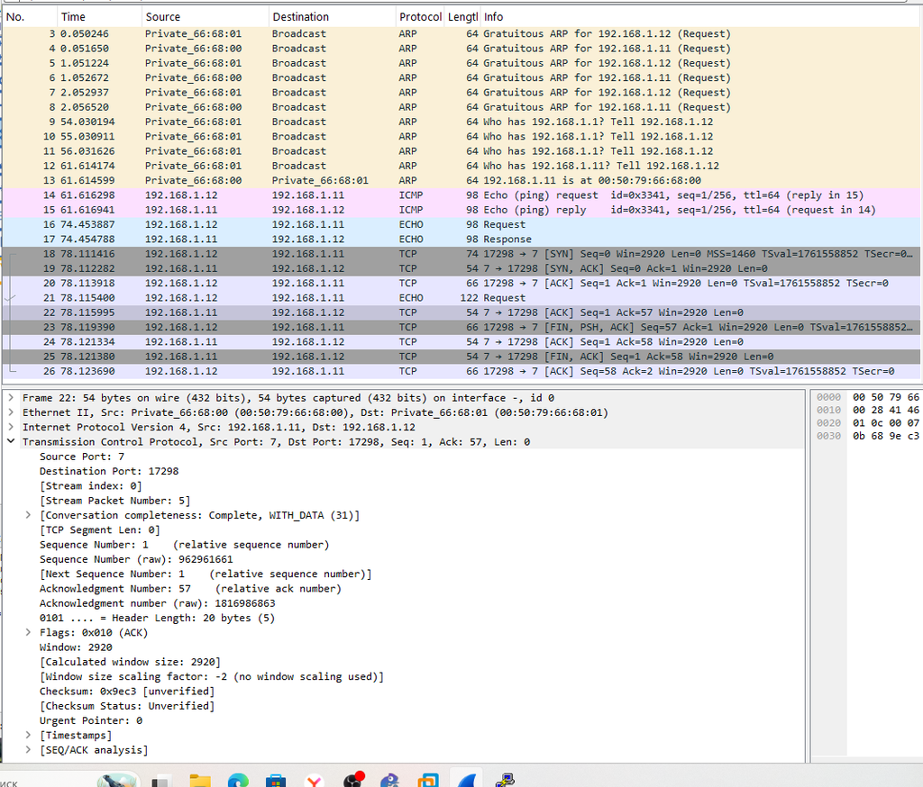

Анализ TCP-пакетов

## Моделирование сети с FRR

Создана сеть с маршрутизатором **FRR**.  
- PC1: IP **192.168.1.10/24**  
- FRR: интерфейс **eth0 – 192.168.1.1/24**

[figure not shown]

Настройка FRR

## Проверка связи

Проверка `ping 192.168.1.1` показала отсутствие потерь.  
В Wireshark видны пакеты **ARP** и **ICMP**, что подтверждает корректную маршрутизацию.

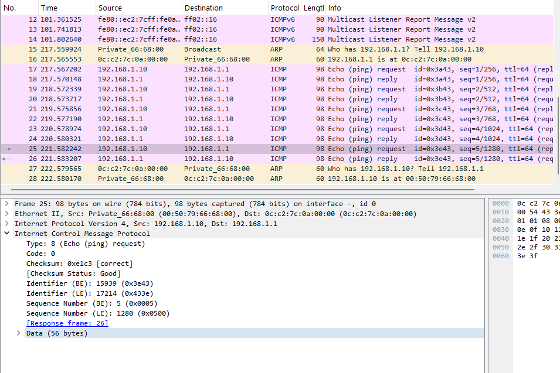

Проверка связи FRR

## Моделирование сети с VyOS

Создана аналогичная топология с маршрутизатором **VyOS**.  
Задано имя устройства и IP-адрес **192.168.1.1/24** на интерфейсе `eth0`.

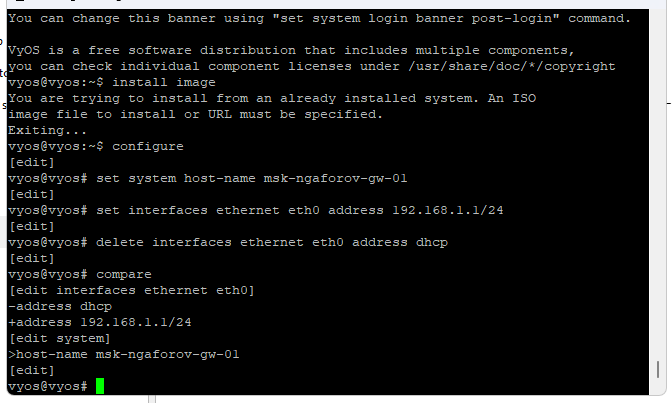

Настройка VyOS

## Проверка ICMP-обмена

ПК успешно взаимодействует с маршрутизатором VyOS через ICMP-запросы.  
Трафик фиксируется в Wireshark, что подтверждает правильность конфигурации сети.

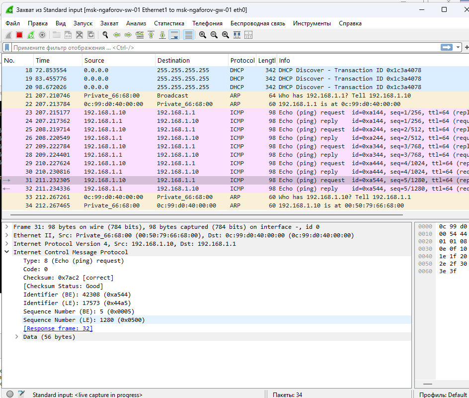

ICMP с VyOS

# Выводы

В ходе лабораторной работы:  
- Изучены принципы настройки сетей в **GNS3**.  
- Проверена работа протоколов **ARP**, **ICMP**, **UDP**, **TCP**.  
- Освоены базовые приёмы анализа трафика в **Wireshark**.  
- Подтверждена корректность установки TCP-соединений по схеме **Three-Way Handshake**.

Результаты подтвердили надёжную работу сетевых протоколов и правильность построения модели сети.